# Task 16

Rachael Smith

June 12, 2020

```r
# Use this R-Chunk to import all your datasets!

#download("http://scriptures.nephi.org/downloads/lds-scriptures.csv.zip", dest = "lds_scrips.zip", mode = "wb")

#unzip("lds_scrips.zip", exdir = "Case_Study_08/Class_Task_16")

scriptures <- read_csv("lds_scrips.zip")
```

1. What is the average verse length (number of words) in the New Testament compared to the Book of Mormon?

```r
bom_nt <- scriptures %>%
  mutate(wc = str_count(scripture_text, "\\W+")) %>%
  group_by(volume_title) %>%
  filter(volume_title == "Book of Mormon" | volume_title == "New Testament") %>%
  summarise(mean_wc = mean(wc), tot_wc = sum(wc)) %>% pander()

  #mutate(word_count = stri_stats_latex(scripture_text)[4])

bom_nt
```

| volume_title | mean_wc | tot_wc |
| --- | --- | --- |
| Book of Mormon | 40.51 | 267520 |
| New Testament | 22.71 | 180703 |

2. How often is the word Jesus in the New Testament compared to the Book of Mormon?

```r
# Use this R-Chunk to clean & wrangle your data!
Jesus_count <- scriptures %>% group_by(volume_title) %>% mutate(Jesus = str_count(scripture_text, "Jesus")) %>% summarise(sum_jesus = sum(Jesus)) %>% pander()

Jesus_count
```

| volume_title | sum_jesus |
| --- | --- |
| Book of Mormon | 184 |
| Doctrine and Covenants | 97 |
| New Testament | 976 |
| Old Testament | 0 |
| Pearl of Great Price | 11 |

3. How does the word count distribution by verse look for each book in the Book of Mormon?

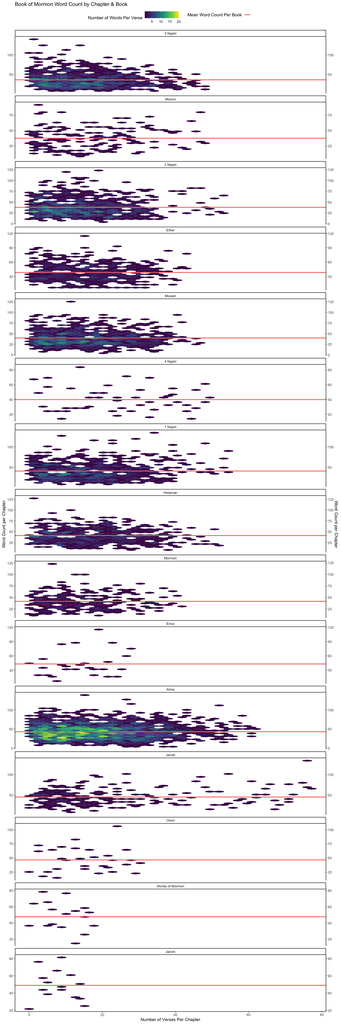

```r
verse_count <- scriptures %>% filter(volume_title == "Book of Mormon") %>% mutate(wc = str_count(scripture_text, "\\W+"))

word_count_summary <- verse_count %>%
  group_by(book_title) %>%
  summarise(mean_word_count = mean(wc)) %>%
  ungroup %>%
  mutate(book_title = factor(book_title),
  book_title = fct_reorder(book_title, mean_word_count))


book_levels <- levels(word_count_summary$book_title)

verse_count <- verse_count %>% mutate(book_title =factor(book_title, levels = book_levels))

ggplot(data =verse_count, aes(x = verse_number, y = wc)) +
  geom_hex() +
  geom_hline(data = word_count_summary, mapping = aes(yintercept = mean_word_count, color = ""), size = 1.0) +
  facet_wrap(~book_title, ncol = 1, scales = "free_y") +
  theme_classic()+
  scale_fill_viridis_c(option = "D")+
  theme(legend.position = "top")+
  scale_y_continuous(sec.axis = dup_axis())+
  labs(title = "Book of Mormon Word Count by Chapter & Book", fill = "Number of Words Per Verse", y = "Word Count per Chapter", x = "Number of Verses Per Chapter", color = "Mean Word Count Per Book")
```

I think the most challenging part of this graph was making sure that it wasn’t showing anything that wasn’t already there. It took several variations to make sure that all of the things were reprented that I wanted to. I like the hexagon shape because it helps us to see how many verses there are for each book, as well as how long eaach verse is. I like that using the hexagon plot, I am able to show multiple things at once, without losing any integrity of my data.

```r
bom <- scriptures %>% filter(volume_title == "Book of Mormon") %>%
  mutate(wc = 0)

for(i in 1:nrow(bom)){
  bom$wc[i] = str_count(bom$scripture_text[i], "\\W+")
}

pander(mosaic::favstats(bom$wc, main = "Summary of Book of Mormon Word Count"))
```

Registered S3 method overwritten by ‘mosaic’: method from  
fortify.SpatialPolygonsDataFrame ggplot2

| min | Q1 | median | Q3 | max | mean | sd | n | missing |
| --- | --- | --- | --- | --- | --- | --- | --- | --- |
| 4 | 27 | 38 | 51 | 142 | 40.51 | 18.51 | 6604 | 0 |

4. count the mean number of ands per verse as proxy for fun on sentences

```r
books <- levels(factor(bom$book_title))

output <- vector("double", length(books))

for(i in 1:length(books)){
  books_only <- bom %>% filter(book_title == books[i])
  narrative <- str_c(books_only$scripture_text, collapse = " ")
  sentences <- stri_split_boundaries(narrative, type = "sentence")

 output[i] = sentences %>% unlist() %>% tibble() %>% mutate(andnum = str_count(., "and")) %>%
    summarise(mean_and = mean(andnum))
 }

output %>% unlist() %>% cbind(books) %>% data.frame() %>% pander()
```

| . | books |
| --- | --- |
| 1.71312584573748 | 1 Nephi |
| 1.64760914760915 | 2 Nephi |
| 2.06666666666667 | 3 Nephi |
| 2.66666666666667 | 4 Nephi |
| 1.91011723838472 | Alma |
| 1.86111111111111 | Enos |
| 1.7852998065764 | Ether |
| 2.18566176470588 | Helaman |
| 1.73962264150943 | Jacob |
| 1.96296296296296 | Jarom |
| 2.07272727272727 | Mormon |
| 1.57386363636364 | Moroni |
| 2.09860788863109 | Mosiah |
| 2 | Omni |
| 2.3 | Words of Mormon |

###### Other options for coding:

```
script$verse_length <- sapply(script$scripture_text, function(x)
  length(unlist(strsplit(as.character(x), "\\W+"))))

  bomnt %>% group_by(volume_title, verse_id) %>% (  mutate(wc = stri_stats_latex(scripture_text)["Words"])

  scriptures$verse_length <- sapply(scriptures$scripture_text, function(x)
  length(unlist(strsplit(as.character(x), "\\W+"))))

wc = str_count(scripture_text, "\\W+"))
```